### Figure 4: Barchart

> This figure shows the difference between the Day 0’s in the delayed and original treatments for metronidazole and ampicillin.

> Uses functions in R scripts folder: stacked.barcharts.r, findStatLetters.r, barplotBeside.r

```r
stackedbarcharts(file = "~/Documents/Github/abxD01/Figure4/abxD01.final.tx.2.subsample.alldelay.forlogscale.csv", fileIDS = "~/Documents/Github/abxD01/Figure4/alldelay_tx2_barchart_ids.csv", divide = TRUE)
```

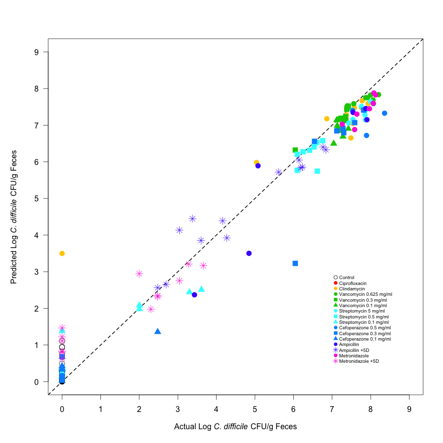

[figure not shown]

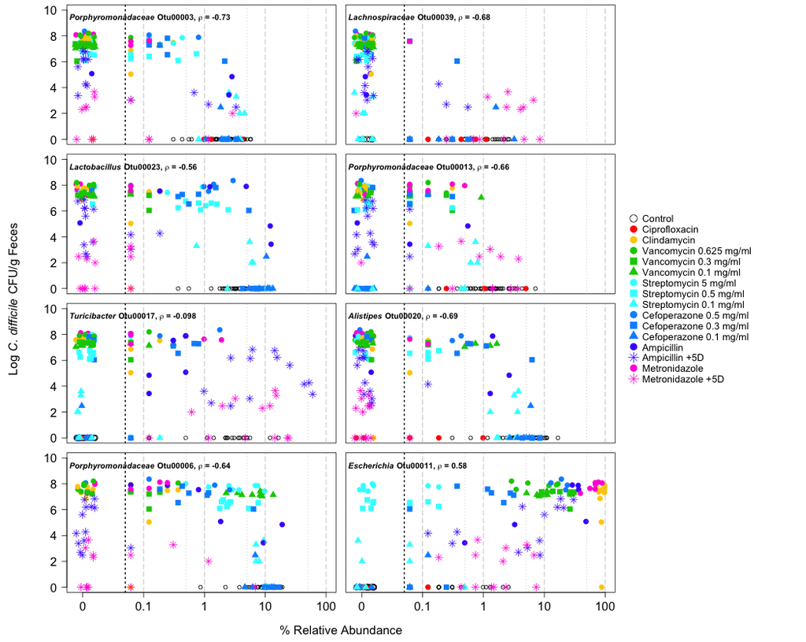

**Figure 5. Random forest model to predict *C. difficile* colonization levels based on the microbiota.** a) The fit of the random forest model by experimental group. The dashed line represents the y=x line. b) The 15 OTUs with the highest percent increase in mean squared error when dropped from the model. c) The percent relative abundance of the top 8 OTUs from (b) on day 0 are plotted against the log<sub>10</sub> *C. difficile* CFU/g feces.

### Evaluating cutoffs for OTU inclusion in Random Forest model

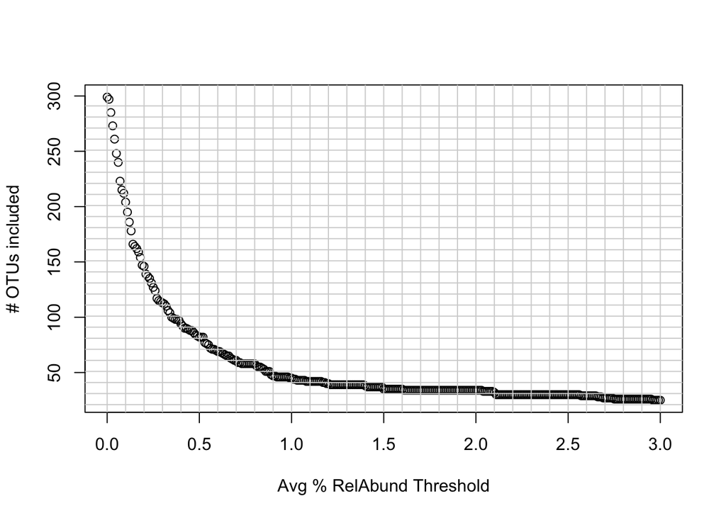

```r
data<-read.csv("~/Desktop/mothur/abxD01/model/abxD01.final.an.unique_list.0.03.subsample.shared.toptitdel.noNewUntr.logtrans.filter16mintot.grouped.csv", header=T)

means <- as.data.frame(matrix(nrow=nlevels(data$expgroup), ncol=0))
row.names(means) <- levels(data$expgroup)
for(i in 3:length(data)){

  df <- aggregate( data[,i] ~ data$expgroup, data=data, mean )
  names(df)[2] <- names(data)[i]

  means <- as.data.frame(cbind( means, df[,2]))
  names(means)[dim(means)[2]] <- names(data)[i]
}

means <- rbind(means, max=-1)
for(j in 1:length(means)){
  means["max", j] <- max(means[,j])
}

means <- rbind(means, relabund=-1)
for(k in 1:length(means)){
  means["relabund", k] <- (means[17,k])/1625
}

means <- rbind(means, percent=-1)
for(k in 1:length(means)){
  means["percent", k] <- (means[18,k])*100
}

meanOTU <- means[,-1] #remove the nextDayCFU column

set <- NULL
set <- seq(0,3, by=0.01)
numOTUxThreshold <- NULL
numOTUxThreshold <- as.data.frame(cbind(numOTUxThreshold, set))
names(numOTUxThreshold)[1] <- "threshold"
numOTUxThreshold <- cbind(numOTUxThreshold, numOTU=NA)
for( i in 1:(length(set)) ) {

  test <- meanOTU[ , meanOTU[19,] >= set[i] ]
  #test2 <- sum( meanOTU[19,] >= set[i] )

  numOTUxThreshold[i, 2] <- length(test)

}

plot(numOTUxThreshold$numOTU ~ numOTUxThreshold$threshold, xlab="Avg % RelAbund Threshold", ylab="# OTUs included")
abline(v=seq(0,3, by=.1), col="light gray")
abline(h=seq(1,300, by=10), col="light gray")
```

> This feeds into the next analysis section.

### Random forest results

```r
otusAtPercAbund <- function(percThresh, meanOTU){
  perc <- meanOTU[ , meanOTU[19,] >= percThresh ]
  otus <- names(perc)[-(length(perc))]
  return(otus)
}

perc<-1
otus <- otusAtPercAbund(perc, meanOTU)

all <- read.csv(file=dataFile, header=T)
cols<- NULL
for(i in 1:(length(otus))){
  cols <-c(cols, which(names(all)==otus[i]))
}
cols <- c(which(names(all)=="Group"), which(names(all)=="nextDayCFU"), cols)

# dose <- all[1:99,cols]
# titr <- all[100:153,cols]
# del <- all[154:179, cols]
# toptit <- all[1:153,cols]
# titdel <- all[c(100:153, 154:179),cols]
# topdel <- all[c(1:99, 154:179),cols]
toptitdel <- all[,cols]
library(randomForest)
toptitdel.rf <- randomForest(nextDayCFU ~ .,
                           data = toptitdel[,-1],  outscale=TRUE,
                           importance=TRUE, proximity=TRUE,
                           keep.forest=TRUE, ntree=5000
)
print(toptitdel.rf)
```

```
##
## Call:
##  randomForest(formula = nextDayCFU ~ ., data = toptitdel[, -1],      outscale = TRUE, importance = TRUE, proximity = TRUE, keep.forest = TRUE,      ntree = 5000)
##                Type of random forest: regression
##                      Number of trees: 5000
## No. of variables tried at each split: 14
##
##           Mean of squared residuals: 1.697149
##                     % Var explained: 85.73
```

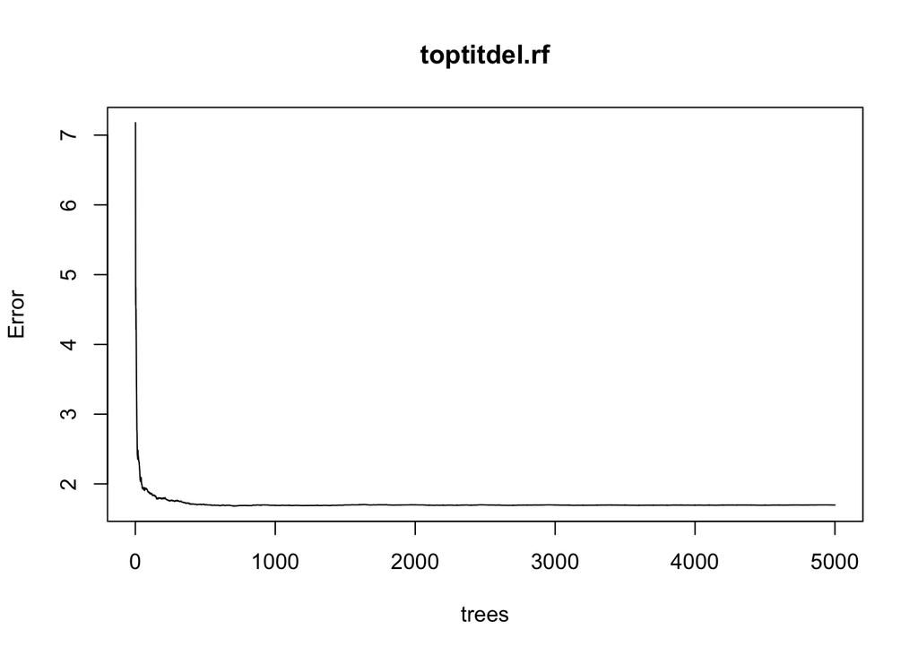

```r
plot(toptitdel.rf)
```

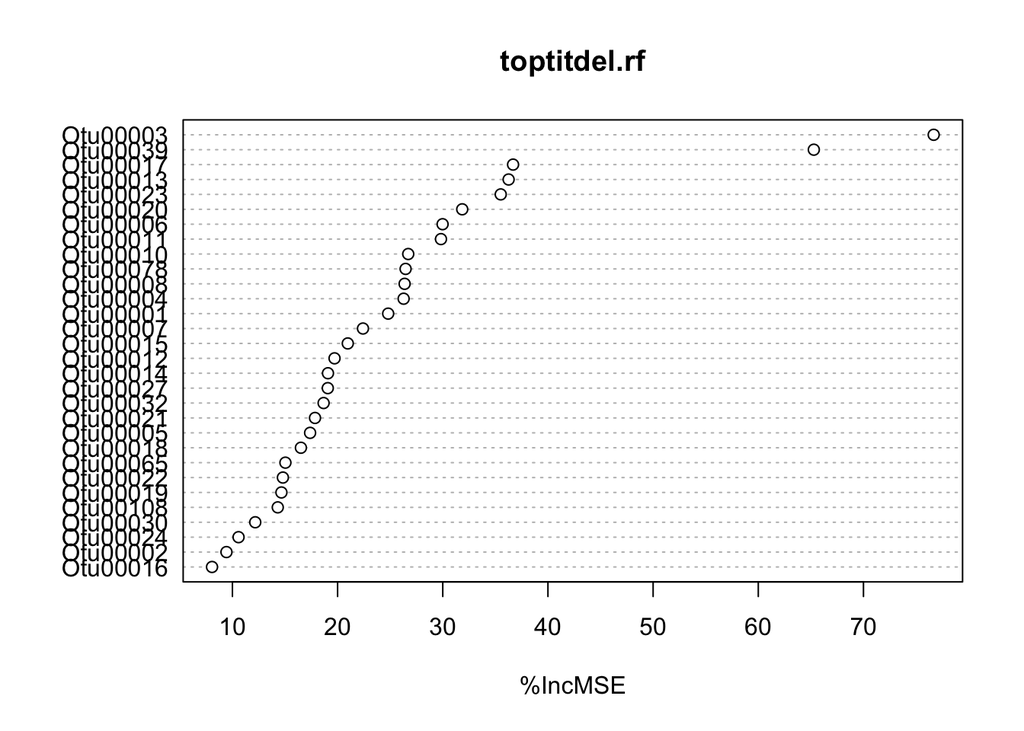

```r
varImpPlot(toptitdel.rf, type=1)
```

```r
imp<-importance(toptitdel.rf)
imp1<-imp[order(imp[,1], decreasing = TRUE),]
#imp2<-imp[order(imp[,2], decreasing = TRUE),]
topimp <- imp1[1:15,]
#toppurity <- imp2[1:15,]
#write.table(topimp, file="~/Desktop/mothur/abxD01/rf/rf.toptitdel.1p.importance.txt", sep="\t", row.names=TRUE)
#write.table(toppurity, file="~/Desktop/mothur/abxD01/rf/rf.toptitdel.1p.importanceNode.txt", sep="\t", row.names=TRUE)
```

### Figure 5A: Evaluating and plotting the fit of the model

```r
predictions <- predict(toptitdel.rf, newdata=toptitdel[,-c(1,2)])
actual <- toptitdel$nextDayCFU
expgroup<- as.character(all[,2])
results<-as.data.frame(cbind(actual, predictions))
colnames(results) <- c( "actual", "predict")

ybar <- apply(results, 2, mean)
num<-sum((results$actual-ybar["actual"])*(results$predict-ybar["predict"]))
denA <- sum((results$actual-ybar["actual"])^2)
denB <- sum((results$predict-ybar["predict"])^2)
rsq <- (num^2)/(denA*denB) #calculated from the square of the sample correlation coefficient, little r squared as opposed to big R squared

results <- cbind(expgroup, results)

#Plot observed vs predicted
#information for plotting
color<-rainbow(7)
colors <- c(control = "black",
          cipro = color[1],
          clinda = "#FFCC00",
          vanc.625 = "#00CC00",
          vanc.3 = "#00CC00",
          vanc.1 = "#00CC00",
          strep5 = "#33FFFF",
          strep.5 = "#33FFFF",
          strep.1 = "#33FFFF",
          cef.5 = color[5],
          cef.3 = color[5],
          cef.1 = color[5],
          amp.5 = color[6],
          amp.5d = color[6],
          metro1 = color[7],
          metro1d = color[7])

# topdose is all circles, middle dose is square,
# low dose is upward pointing triangle, delayed is starburst
pch <- c(control = 1,
         cipro = 16,
         clinda = 16,
         vanc.625 = 16,
         vanc.3 = 15,
         vanc.1 = 17,
         strep5 = 16,
         strep.5 = 15,
         strep.1 = 17,
         cef.5 = 16,
         cef.3 = 15,
         cef.1 = 17,
         amp.5 = 16,
         amp.5d = 8,
         metro1 = 16,
         metro1d = 8)

#these are needed for the legend
legend.labels <- c(control = "Control",
            cipro = "Ciprofloxacin",
            clinda = "Clindamycin",
            vanc.625 = "Vancomycin 0.625 mg/ml",
            vanc.3 = "Vancomycin 0.3 mg/ml",
            vanc.1 = "Vancomycin 0.1 mg/ml",
            strep5 = "Streptomycin 5 mg/ml",
            strep.5 = "Streptomycin 0.5 mg/ml",
            strep.1 = "Streptomycin 0.1 mg/ml",
            cef.5 = "Cefoperazone 0.5 mg/ml",
            cef.3 = "Cefoperazone 0.3 mg/ml",
            cef.1 = "Cefoperazone 0.1 mg/ml",
            amp.5 = "Ampicillin",
            amp.5d = "Ampicillin +5D",
            metro1 = "Metronidazole",
            metro1d = "Metronidazole +5D")

treatments <- c(control = "Control",
            cipro = "Ciprofloxacin",
            clinda = "Clindamycin",
            vanc.625 = "Vancomycin High",
            vanc.3 = "Vancomycin Medium",
            vanc.1 = "Vancomycin Low",
            strep5 = "Streptomycin High",
            strep.5 = "Streptomycin Medium",
            strep.1 = "Streptomycin Low",
            cef.5 = "Cefoperazone High",
            cef.3 = "Cefoperazone Medium",
            cef.1 = "Cefoperazone Low",
            amp.5 = "Ampicillin",
            amp.5d = "Ampicillin +5D",
            metro1 = "Metronidazole",
            metro1d = "Metronidazole +5D")

par(mfrow=c(1, 1))
par(mar=c(5, 5, 4, 2) +0.1, mgp=c(3, 1, 0), las=1) #default is 5.1 4.1 4.1 2.1, bot/left/top/right, also default mgp is c(3,1,0)
plot(results[results[,1]=="control",2],
     results[results[,1]=="control",3],
     main="",
     ylab=expression(paste("Predicted Log ", italic("C. difficile"), " CFU/g Feces")),
     xlab=expression(paste("Actual Log ", italic("C. difficile"), " CFU/g Feces")),
     ylim=c(0,9), xlim=c(0,9), xaxt='n', yaxt='n', cex=1.5)
#mtext(bquote("r"^"2" ~ " = " ~ .(signif(rsq, 3))), side=3, line=0)
abline(a=0, b=1, lty="dashed", lwd=2, col="black")
axis(1, at = c(0:9), labels=c(0:9))
axis(2, at = c(0:9), labels=c(0:9))

for(i in 2:(length(legend.labels))){
  points(results[results[,1]==names(legend.labels)[i],2],
         results[results[,1]==names(legend.labels)[i],3],
         col=colors[i], pch=pch[i], cex=1.5)
}
legend(x=7, y=3, legend=legend.labels, pch=pch, col=colors, pt.cex=1,  cex=.6, bty="n")
```

### Figure 5B: Importance Plot

```r
topimp<-topimp[order(topimp[,1], decreasing=FALSE),]
ids <- read.csv(file = "~/Documents/Github/abxD01/Figure5/rf.toptitdel.1p.importance.ids.csv", header = TRUE)
labels<- paste0(ids$name, " (", ids$otuname, ")")
par(mfrow=c(1, 1)) #+1 to give extra labeling space
par(mar=c(5, 15, 0.5, 2) +0.1, mgp=c(3, 1, 0)) #default is 5.1 4.1 4.1 2.1, bot/left/top/right, also default mgp is c(3,1,0)
plot(topimp[,1], 1:15, xlab="% Increase in Mean Squared Error", yaxt="n", ylab="", pch=16, cex=1.5, xlim=c(20, 80))
axis(2, at = c(1:15), labels = labels, las=1, cex.axis=.9 )
abline(h=c(1:15), lty="dashed", col='black')
```

### Testing a random forest model with only OTUs 3 and 39

```r
test3.39 <- toptitdel[,c("Group","nextDayCFU","Otu00003", "Otu00039")]

rf.test3.39 <- randomForest(nextDayCFU ~ .,
                           data = test3.39[,-1],  outscale=TRUE,
                           importance=TRUE, proximity=TRUE,
                           keep.forest=TRUE, ntree=5000
)
print(rf.test3.39)
```

```
##
## Call:
##  randomForest(formula = nextDayCFU ~ ., data = test3.39[, -1],      outscale = TRUE, importance = TRUE, proximity = TRUE, keep.forest = TRUE,      ntree = 5000)
##                Type of random forest: regression
##                      Number of trees: 5000
## No. of variables tried at each split: 1
##
##           Mean of squared residuals: 2.500185
##                     % Var explained: 78.98
```

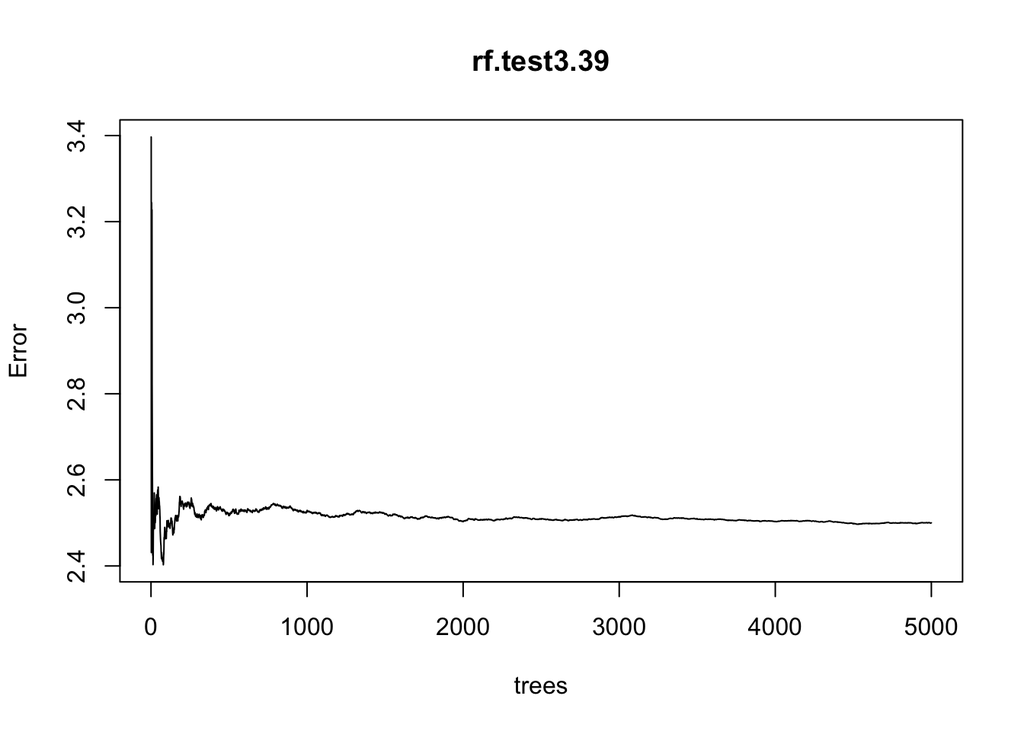

```r
plot(rf.test3.39)
```

```r
predictions <- predict(rf.test3.39, newdata=test3.39[,-c(1,2)])
actual <- test3.39$nextDayCFU
test.results<-as.data.frame(cbind(actual, predictions))
colnames(test.results) <- c( "actual", "predict")

ybar <- apply(test.results, 2, mean)
num<-sum((test.results$actual-ybar["actual"])*(test.results$predict-ybar["predict"]))
denA <- sum((test.results$actual-ybar["actual"])^2)
denB <- sum((test.results$predict-ybar["predict"])^2)
test.rsq <- (num^2)/(denA*denB)
```

### Correlation over all three datasets with *C. difficile* levels

```r
#First the correlation calculations that were put on the graph:
c<-1
otu <- c()
cor.spear <- c()
pval.spear <- c()
cor.ken <- c()
pval.ken <- c()
for(i in 3:length(toptitdel)){
  otu[c] <- colnames(toptitdel[i])
  cor.spear[c] <- cor.test(toptitdel[,2],toptitdel[,i], method="spearman")$estimate
  pval.spear[c] <- cor.test(toptitdel[,2],toptitdel[,i], method="spearman")$p.value
  cor.ken[c] <- cor.test(toptitdel[,2],toptitdel[,i], method="kendall")$estimate #good to see because kendall handles ties
  pval.ken[c] <- cor.test(toptitdel[,2],toptitdel[,i], method="kendall")$p.value #but only works if this is tao-b and not tao-a which im not sure about
  c <- c+1
}
pval.spear<-p.adjust(pval.spear, method='BH') #adjust for multiple comparisons
pval.ken<-p.adjust(pval.ken, method='BH') #adjust for multiple comparisons

results = NULL
results <- matrix(c(otu, cor.spear, pval.spear, cor.ken, pval.ken), ncol=5)
colnames(results) <- c('otu','corSpear','pvalSpear', "corKen", "pvalKen")
results <- results[order(results[,3]),]  #order by pvalue column=3
#write.table(results[1:dim(results)[1],], file="~/Desktop/mothur/abxD01/correlation/toptidel.1p.correl.txt", sep="\t", row.names=FALSE)
print(results[1:dim(results)[1],])
```

> From this file I selected the top 8 OTUs identified by random forest’s increase in mean squared error measurement to graph (next section).

### Figure 5C: OTU abundance vs. *C. difficile* abundance

```r
corrs<-read.csv(file="~/Desktop/mothur/abxD01/correlation/toptitdel.correlation.impOTUs.csv", header=TRUE)
corrs <- corrs[1:8,]
otunames <-  row.names(topimp)[15:8]
graphID <- ids[15:8,c(1,3)]

graphOTUxCD(otus = otunames, ids = graphID, corrs = corrs)
```

### Discussion

Previous work characterizing the microbiome’s of human and mouse hosts in the context of CDI provide glimpses into potentially protective and alternatively susceptible community structures, i.e. which bacteria are present and their abundance. Cross-sectional investigations have characterized the microbiota of patients in the hospital with and without a *C. difficile* infection (CDI) and compared to healthy controls. These studies found patients with *C. difficile* tended to have a reduction in numbers of Clostridiales Incertae Sedis XI (Vincent et al), Lachnospiraceae, Ruminococcaceae, and Bacteroides (Schubert et al). These studies however lack the baseline healthy state of the microbiota, which preclude them from assessing risk of *C. difficile*. Murine models of CDI have the advantage of observing the specific changes that occur before and after controlled perturbations and the introduction of *C. difficile*. Communities with low levels of CR were associated with blooms in either Lactobacillaceae (cefoperazone-induced) (Theriot, 2014, bassis, 2014), Proteobacteria (induced by either clinda+5abx cocktail, clinda alone, or tigecycline) (Reeves, 2011, Buffie, 2011, Bassis 2014). Lachnospiraceae is associated with resistance to *C. difficile* infection (Reeves 2011) and has been directly shown to decrease colonization through mono-colonization studies in germfree mice (Reeves 2012).

Even fewer studies attempt to model these observational changes in the microbiome following perturbation. Using the time series data gathered from the *C. difficile* challenge of clindamycin-treated mice (Buffie 2011), a Lotka-Volterra dyamics-based framework was built which incorporates both time and accounts for external perturbations (Stein 2013). They identified a subset of their network, containing Blautia, Akkermansia, and Coprobacillus, as having a negative relationship with *C. difficile*, while alternatively Enterococcus had a positive relationship.

OTU39—Eubacterium ventriosum (94%), eubacterium rectale (93%), roseburia intestinalis/hominis/faecis (93%) (positively correlated to differences observed in discordant MZ twins for BMI—more abundant in higher BMI siblings… these are all butyrate producers, also capable of degrading fiber) FOS—fructooligosaccharides produced by degredation of inulin or polyfructose

Any interesting points about the results? Mechanisms? Competition—ask matt if they are good? Proteobacteria could definitely play a role in susceptibility—creating an environment fit for cdiff… what ways could all those other bugs be making a bad environment for cdiff? Using up bile acids/germinants.., with those bugs gone freeing up sugars, … maybe connecting a lot more to some of caseys metabolome paper, and how mine would fit that

o Limitations • No smaller intervals? Of cdiff levels, or changes in microbiota • Porphyromonadaceae is more prevalent in mice… so might not be as relevant for humans • Different strains of cdiff have different microbiota requirements to protect? • Doesn’t get at function… ? • Collect more data to continue to improve our microbiome modeling abilities,

o Contribution to the field, positive spins • PROBIOTICS • Possible global effects? CR against other GI pathogens? • clinical applications—PCR diagnostic for risk

The final paragraph should highlight the main conclusion(s), and provide some indication of the direction future research should take. (for and I and I mention host) -therapeutic: continuously supply probiotics while lowering inflammation of the host (get host side back to normal state in tandem, via drugs? diet)… so attack the issue of CDI from both the microbiota end and host end… microbiota-host-pathogen triangle… …squeeze it out (eg. clindamycin clearance? If compared pathology of host at diff days along 10d for clindamycin vs cef/met/amp (these other ones that are high in cdiff coloniz), is host or toxin diff?… why does clinda clear after being CDhigh but no other ABX?)

The human microbiome is complex; it has been observed that there is no identifiable “core” microbiome that all humans share (Turnbaugh 2009). It’s been observed that there is a high level of interindividual variation among healthy individuals’ microbiomes (Costello 2009). Thus the definition of a healthy microbiome is one that encompasses a wide range of microbiota structures, each one evolved with their host. It’s highly likely there is no one size fits all solution for the treatment or prevention of CDI. Thus characterizing the relationships within the microbiome are important in the context of a community. Need more studies that look at the level of the community as a whole in CR over the effect of single bugs. Examples of papers looking at combinations/subsets of bacteria in CR

[output not shown]

Bacteria within a community setting may act differently in the context of other bacterial species.

[using this time model for the metro… I wonder if it doesn’t work because of the time difference in the amount of recovery time? I’m picturing sort of an echo/ripple effect where at first the waves, or changes, are really large and then over time that rate of change of the community slows and the changes less pronounced/smaller. In this context the metro communities were at a stage farther along in the echo, meaning changes not happening as fast. Whereas the measurements we’ve taken and are using to make predictions are from the community at a time when you expect more/bigger/faster changes. So then the results are calculated assuming one rate but actually in a different (slower). By this image, the initial strength of the perturbation matters too.]